# Super Smash Bros. Tournament Locations

Jason Chhay

3/1/2020

#### [Back to projects page](https://jwchhay.github.io/projects.html)

*The following data is from https://statsmash.io/data/. This website holds a large amount of information about tournaments for Super Smash Bros. Melee and Super Smash Bros. Ultimate. It’s actually an interesting website, as it has things like ELO rankings for players and matchup histories between players.*

### Hold up, what’s “Melee” and “Ultimate”?

For those unaware, Super Smash Bros. is a fighting game series made by Nintendo. It has a diehard fanbase, and those who claim “I’m pretty good at Smash” can duke it out in tournaments. Usually, twitch.tv has streams of these tournaments. Two games out of the five within the series are still played in tournaments: Super Smash Bros. Melee (2001) and Super Smash Bros. Ultimate (2018). Despite Melee having been released in 2001, it is still played a lot.

Anyways, I was curious where the majority of these tournaments were held. I have an idea that most tournaments are held in America, but just to make sure, I made a map of where these tournaments really are taking place. I look at both Melee and Ultimate data, which come from the following datasets found on the website (melee_tournament.csv and ultimate_tournament.csv).

This is a world map of the tournaments that have taken place for Melee from 2018 until the present.

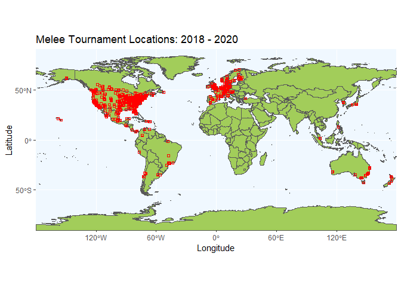

Confirming my suspicions, there are a majority of tournaments held in America. To my surprise, it looks like Europe is right behind America for tournament frequency. Let’s look at the map for Ultimate and see if the trend is similar.

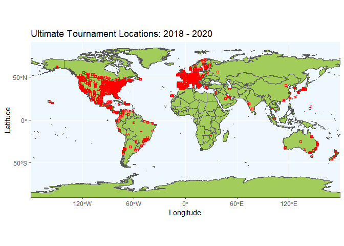

The distribution for this map of Ultimate tournaments looks like the Melee one, except more populated. Notice how some places in the world have tournaments now, like certain parts of Africa, India, etc.

Melee is very equipment specific, in that you need old CRT TVs as well as a disc of the game (for legal purposes at big tournaments) and a Nintendo Gamecube to play. If you look at pictures of Melee tournaments, there is a lot of equipment needed. Not only that, but the game is old, so getting a copy of Melee can be difficult.

For Ultimate, all you need is the Nintendo Switch, a copy of the game (which can be digital or in a cartridge), and a monitor. The game is sold on the Nintendo eShop, and monitors are much more plentiful than CRT TVs. Also, wi-fi tournaments are more possible with Ultimate (you can set up online on Melee, but it requires third-party software).

These two factors help to explain a part of why there are more tournaments for Ultimate.

### Maybe we should look at some more maps…

Just out of curiousity, let’s compare certain regions where both games are played prevalently. Here’s the distribution for America, the biggest region for tournaments.

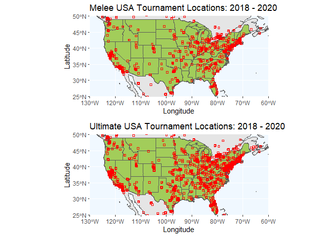

Now here’s the distribution for Europe, the second biggest region for tournaments.

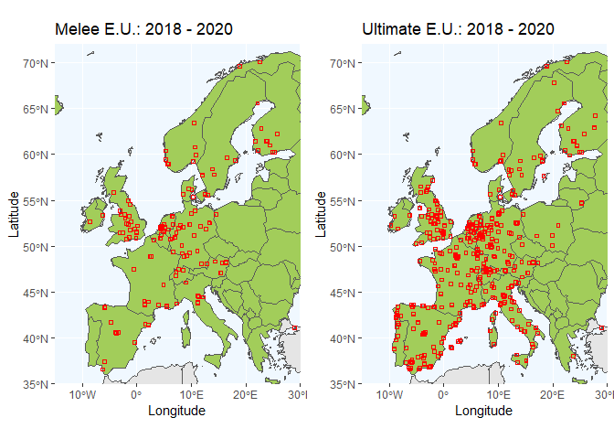

Ultimate does seem to have a lot more tournaments than Melee in these regions.

Speaking of these games, there is a ranking system for their competitive players. Players are rated based on their performances at tournaments. Notably, Japanese players are prevalent in the top 100 for Ultimate, while their presence in Melee is very small. Also, the best player for Ultimate, MKLeo, comes from Mexico, which also has a strong scene for Smash Bros. Let’s look at Mexico and Japan and their communities for the games.

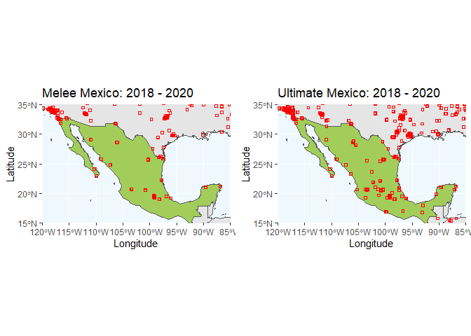

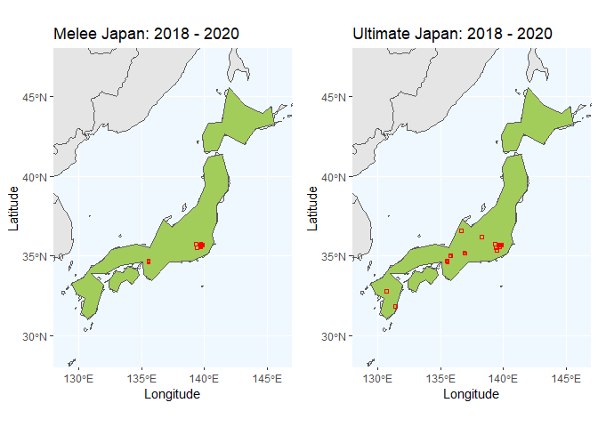

So how are the Japanese and Mexican players so highly rated on the top 100 despite their countries not having many tournaments? Simply put, they travel to the United States to compete in the big tournaments. With some tournaments having entrants in the thousands in the U.S., it’s surprising that these players can afford to travel from somewhere like Japan to the U.S. so often. Especially since not being in the final top 8 of a tournament can leave you empty-handed, as prize money is usually dedicated to top 8.

Hopefully, you now know just how popular these two games are. Will Smash Bros. become even more popular in the future? Will it overtake games like Street Fighter and Tekken as the premier fighting game? I don’t know for certain, but I’d say the community is flourishing more than ever. Hit up your local Smash scene and see for yourself. Maybe you too will even become addicted to playing this wacky fighting “party” game.

Thanks for reading.